# LLM 기반 IP 개발 시스템 프로젝트 승인 요청서

## 1페이지 요약

### 먼저 보는 전제

이번 결재는 「글도비」를 `비정식 혼합 운영 단계`에서 `회사 운영 체계`로 전환할지 판단하는 승인이다. 운영 단위는 `2026-04~12`, `총 27작품`이며, 비용 산정 기준은 `평균 월 3작품`이다.

### 1. 무엇을 승인해 달라는가

이번에 승인받고자 하는 사항은 아래 세 가지다.

1. `2026-04~12 운영 전환 1단계 예산 약 2,200~2,900만원 + a 상한 승인`
2. `Vertex AI 계정·예산·Batch API 운영 승인`
3. `연내 총 27작품 목표 기준 운영 승인`

권리 처리, 운영 책임, 예외 프로바이더는 위 3개 승인 범위를 집행하기 위한 `부속 운영원칙·조건`으로 본문에서 다룬다. 글도비는 소설 집필 AI가 아니라, **IP를 대량으로 테스트하는 생산 인프라**다.

이번 운영 전환의 사업적 목적은 `선인세 없음`, `RS 없음`, `IP 통제 가능`, `지속 생산 시스템 확보`에 있다.

| 항목 | 월 비용 | 검토 기간 합계 / 기준 단가 | 비고 |
| --- | --- | --- | --- |
| Codex 구독 | 약 30만원 | 약 270만원 | 전처리·유지 |
| Claude Code Pro Max | 약 30만원 | 약 270만원 | 감리·교차검증 |
| Vertex AI API | 약 132~210만원 | 약 1,190~1,890만원 | 기본 생산비 |
| 개발비/서버비/기타 | 약 50만원 | 약 450만원 | 인프라·예비 |
| Grok API(선택) | +a | +a | 상부 요구 19금 HL 예외 |
| **합계(정확합)** | **약 242~320만원 + a** | **약 2,178~2,880만원 + a** | 2026-04~12 |

주: `Codex`, `Claude Code Pro Max`는 `세금 포함 예산 가정`이며, `개발비/서버비/기타`는 `9개월 450만원` 기준으로 재산정했다.

### 2. 왜 천만 단위 예산인가

핵심 숫자는 `27작품`, `총원가 약 2,200~2,900만원 + a`, `보수적 하한선(P25) 약 4,503만원`이다.

남성향 `60개월 매출 추적 자료` 기준 `27작품 포트폴리오`의 `출시 후 12개월 누적 순매출 보수적 하한선(P25)`은 약 `4,503만원`이다. 이번 예산은 완성품 구매가 아니라 **검증 속도를 늦추지 않기 위한 운영 전환 비용**이다.

### 3. 왜 지금 승인해야 하는가

지금 승인하지 않으면 `회사 자산화`, `Vertex AI 기반 운영 통제`, `4월 말 작품 생산 가능성 closure`가 함께 지연된다.

또한 이 접근은 외부의 `장편 생성`, `서사 일관성`, `검수 루프`, `보조 memory/retrieval` 흐름과도 정렬되어 있다.

지금까지는 `일부 회사 비용 집행`과 `일부 개인 부담`이 혼재된 `비정식 운영` 성격이 강했다. 주요 병목 중 하나는 `예산 제약에 따른 로그 확보·분석 속도 저하`였고, 그만큼 운영 전환 판단에 필요한 검증 속도도 충분히 끌어올리기 어려웠다. 현재 단계는 `1 arc 기준선` 위에서 `연속성 결함 수렴을 위한 canary run + log-driven remediation 3아크런(약 15화) 반복 사이클`을 돌리고 있는 `internal MVP validation 진행 단계`다.

## 목차

- 1페이지 요약
- 2. 재무적 판단
- 3. 기술적 판단
- 4. 외부 현황 및 승인 판단

## 2. 재무적 판단

재무 판단의 핵심은 이 안건이 `즉시 현금회수 보장`을 주장하는 문서가 아니라, `운영 전환 1단계 총원가가 내부 시장 기준선에서 과도한 숫자인가`를 판단하는 승인서라는 점이다.

### 2.1 먼저 27작품 전제를 본다

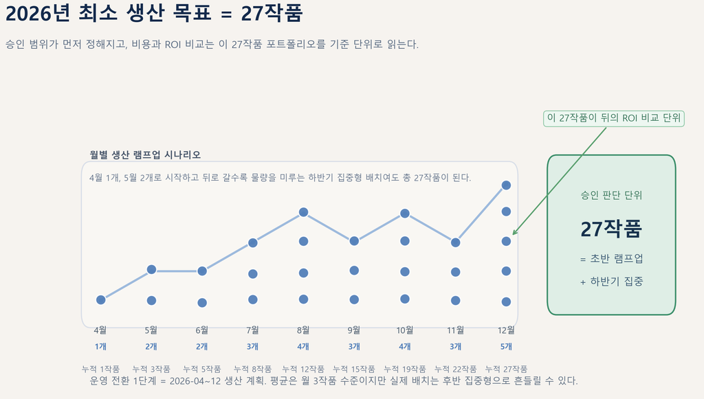

### 2.2 분포 안에서 이 선을 본다

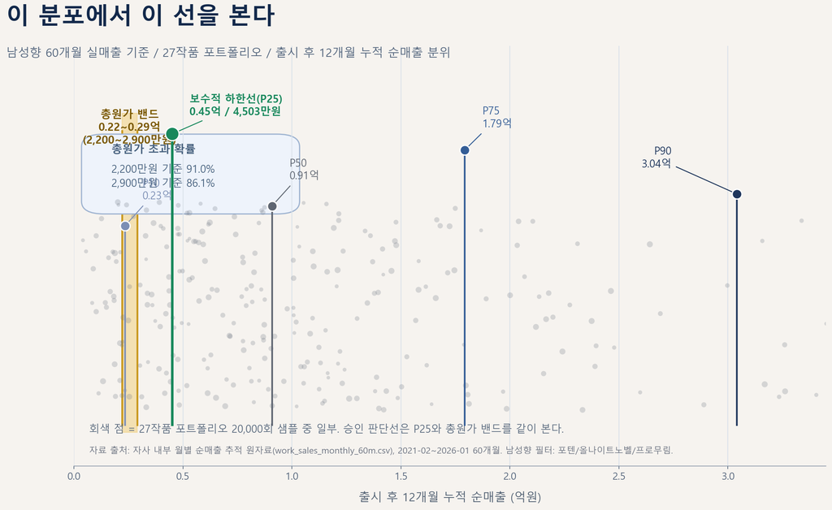

1. 비교 단위는 승인 범위인 `27작품 포트폴리오`다.
2. 매출 단위는 각 작품의 `출시 후 12개월 누적 순매출`이다.
3. 이 비교는 `동기간 현금회수`가 아니라 `포트폴리오 회수 가능성 기준선` 판단이다.
4. 시각화는 `P10/P25/P50/P75/P90` 분위선과 샘플 점을 함께 두되, 승인 판단 기준선은 `보수적 하한선(P25)`와 `총원가 밴드`다.
5. 자료 출처는 `자사 내부 월별 순매출 추적 원자료(work_sales_monthly_60m.csv)`이며, 판매월 범위는 `2021-02~2026-01`의 `60개월`이다.

### 2.3 이 문서가 재무적으로 묻는 질문

이 승인요청서는 `작품 1개가 바로 돈이 되느냐`를 묻는 문서라기보다, `2026-04~12` 동안 `총 27작품(평균 월 3작품)`을 운영 가능한 회사 체계로 올릴 때 `27작품 포트폴리오가 시장 기준선 대비 회수 가능한 구조인가`를 묻는 문서에 가깝다. 따라서 재무 판단 단위도 `작품별 상방 추정치`보다 `포트폴리오 기준 회수 가능성`에 두는 편이 적절하다.

재무팀이 봐야 할 핵심 질문은 두 가지다.

1. 운영 전환 1단계 기본 총원가가 얼마인가.
2. 그 총원가가 내부 시장 자료 기준에서 완전히 분리된 무리한 숫자인가.

### 2.4 비용 구조는 어떻게 잡았는가

비용은 `고정비`, `운영형 변동비`, `예외 비용`, `실험성 비용`으로 구분해 읽는 편이 적절하다.

| 구분 | 기준 | 2026-04~12 합계 | 해석 |
| --- | --- | --- | --- |
| Codex 구독 | 약 30만원/월 | 약 270만원 | 세금 포함 예산 가정 |
| Claude Code Pro Max | 약 30만원/월 | 약 270만원 | 세금 포함 예산 가정 |
| Vertex AI API | 약 132~210만원/월 | 약 1,190~1,890만원 | 기본 생산 경로 |
| 개발비/서버비/기타 | 약 50만원/월 | 약 450만원 | 인프라, 예비, 운영 |
| Grok API | `+a` | `+a` | 상부 요구 `19금 성인 HL` 프로젝트 예외 |
| 합계(정확합) |  | 약 2,178~2,880만원 + a | 승인 밴드상 약 2,200~2,900만원 + a |

이 표에서 중요한 점은 세 가지다.

1. `Vertex AI API`는 기본 운영비다.
2. `Grok +a`는 상시 비용이 아니라, 상부가 `19금 성인 HL` 프로젝트를 요구할 때만 여는 예외 경로 비용이다.
3. `관리형 파인튜닝 비용`은 이 승인 범위의 기본 운영비에 포함하지 않는다.

운영 가정은 아래처럼 둔다.

1. Google API 실측 기준 `1 arc 약 9,000원`
2. `Vertex Batch API` 병행 시 운영 가정 `1 arc 약 6,300원`
3. `작품당 70 arc`, `평균 월 3작품` 기준으로 Vertex 비용을 산정

### 2.5 손익분기 공식

```
Google API 실측 단가
= 1 arc 약 9,000원

Vertex AI Batch API 병행(약 30% 할인 예상) 적용 단가
= 9,000원 x 0.7
= 약 6,300원/arc

작품당 Vertex 비용 (기본)
= 70 arc x 0.63만원
= 약 44만원

작품당 Vertex 비용 (reject 감안)
= ~70만원

월 Vertex 비용
= 3작품 x 44~70만원
= 약 132~210만원

검토 기간 Vertex 비용
= 9개월 x 132~210만원
= 약 1,190~1,890만원

고정 구독비
= Codex 270만원 + Claude Code 270만원
= 540만원

개발비/서버비/기타 운영비
= 450만원

총비용
= 540만원 + Vertex 1,190~1,890만원 + 개발비/기타 450만원 + 예외 프로바이더(+a)
= 약 2,178~2,880만원 + a
= 승인 밴드상 약 2,200~2,900만원 + a

검토 기간 총생산량
= 9개월 x 평균 월 3작품
= 27작품

예외 프로바이더 제외 기준 작품당 총원가
= 약 2,178~2,880만원 / 27작품
= 약 80.7~106.7만원
```

이 문서에서는 작품당 매출이나 최종 ROI를 단정하지 않는다. 현재 손익 공식은 `운영 전환 1단계 예산 승인` 여부를 판단하기 위한 기준선이다.

### 2.6 남성향 매출 기준선과 통계 자료

본 문서의 재무 해석은 `개별 작품 1개 매출 예측`이 아니라, `이번 승인 범위인 27작품 포트폴리오가 시장 기준선상 기본 총원가를 상회할 수 있는가`를 평가하는 데 목적이 있다. 현재 확보한 `남성향 60개월 실매출` 자료는 바로 이 기준선을 설정하기 위해 사용했다. 따라서 해석 단위 역시 `개별 작품 점추정(point estimate)`보다 `포트폴리오 분포(distribution)`와 `보수적 분위수(quantile)`에 두는 것이 타당하다.

분석에 사용한 원자료는 `자사 내부 월별 순매출 추적 원자료(work_sales_monthly_60m.csv)`다. 판매월 범위는 `2021-02`부터 `2026-01`까지 `정확히 60개월`이며, 이 원자료에서 `포텐`, `올나이트노벨`, `프로무림` 행만 남겨 남성향 모집단(population)을 구성했다.

분석 설계는 아래와 같다.

1. 출판사가 `포텐`, `올나이트노벨`, `프로무림`인 행만 남겨 남성향 모집단으로 본다.
2. 입력 자료는 이미 `순매출` 기준이므로 비용선과 직접 비교한다.
3. 작품 단위는 제목 중복 왜곡을 피하기 위해 `작품 + 작가` 기준으로 묶었다.
4. `12개월 관측 완료 작품 1,699개`를 모집단으로 두고, `27작품 포트폴리오`를 `비복원 무작위추출(random sampling without replacement)` 방식으로 `20,000회` 반복해 `경험적 분포(empirical distribution)`를 추정했다.
5. 계산 방식은 실무적으로 `몬테카를로 시뮬레이션(Monte Carlo simulation)`에 해당하며, `첫 관측월 = 첫 판매월`로 간주한 보수적 전체 모집단(`all_12m`)을 메인 기준선으로 사용했다.

문서에서 사용하는 통계 산식은 아래와 같이 정의한다.

```
모집단
X = {x1, x2, ..., x1699}
xi = i번째 작품의 출시 후 12개월 누적 순매출

포트폴리오 총순매출
Sk = xj1 + xj2 + ... + xjk
  where {j1, ..., jk} 는 모집단 X에서 비복원 무작위추출한 k개 작품

이번 승인 범위의 기준 단위
k = 27

경험적 분포 추정
S27^(1), S27^(2), ... , S27^(20000)
= 27작품 포트폴리오 총순매출을 20,000회 반복 샘플링한 값

보수적 하한 분위수
P25 = Q0.25(S27)
= 27작품 총순매출 경험적 분포의 25% 분위수

총원가 초과 확률
Pr(S27 >= C)
= 20,000회 샘플 중 총순매출이 총원가 C를 넘긴 비율

여기서
C ∈ {22,000,000원, 29,000,000원}
```

실무상 재무 방어에 필요한 관련 파일명은 아래 다섯 개다.

- `work_sales_monthly_60m.csv`
- `work_sales_monthly_by_work_60m_male_only.csv`
- `work_sales_work_profile_male_only.csv`
- `work_sales_roi_portfolio_baseline_male_only.csv`
- `work_sales_roi_portfolio_sensitivity_male_only.csv`

핵심 결과는 아래와 같다.

| 지표 | 값 | 해석 |
| --- | --- | --- |
| 남성향 12개월 관측 완료 작품 수 | 1,699작품 | `작품 + 작가` 기준 |
| 27작품 포트폴리오 P10 | 약 2,335만원 | 좌측 꼬리(left tail)에 가까운 매우 보수적 구간 |
| 27작품 포트폴리오 P25 | 약 4,503만원 | 승인 판단에 쓰는 보수적 하한 분위수 |
| 27작품 포트폴리오 P50 | 약 9,085만원 | 중앙값(median) 기준선 |
| 27작품 포트폴리오 P75 | 약 1억 7,929만원 | 분포 상단 구간 진입선 |
| 총원가 2,200만원 초과 확률 | 91.0% | 보수적 전체 모집단 기준 |
| 총원가 2,900만원 초과 확률 | 86.1% | 보수적 전체 모집단 기준 |

여기서 `27작품`은 통계가 탐색적으로 도출한 최적값이 아니라, `평균 월 3작품 x 9개월`이라는 승인 범위에서 먼저 정한 운영 단위다. 통계는 이 운영 단위가 내부 시장 기준선과 현저히 괴리된 가정이 아닌지를 검증하는 용도로 사용했다.

동일한 추정 절차를 포트폴리오 크기 `18/24/27/30`에 적용한 `민감도 분석(sensitivity analysis)` 결과는 아래와 같다.

| 포트폴리오 크기 | P25 12개월 누적 순매출 | 총원가 2,200만원 초과 확률 | 총원가 2,900만원 초과 확률 | 해석 |
| --- | --- | --- | --- | --- |
| 18작품 | 약 2,196만원 | 74.9% | 67.6% | 하단 원가선과 거의 맞닿는 보수 구간 |
| 24작품 | 약 3,657만원 | 87.5% | 81.2% | 상단 원가선을 넘기는 여유가 생김 |
| 27작품 | 약 4,533만원 | 91.4% | 86.4% | 민감도 비교용 기준행 |
| 30작품 | 약 5,394만원 | 94.2% | 89.9% | 통계 여유는 더 크지만 운영 부담도 증가 |

주: 본문 본선 수치 `P25 약 4,503만원`, `총원가 2,200만원 초과 확률 91.0%`, `총원가 2,900만원 초과 확률 86.1%`은 `work_sales_roi_portfolio_baseline_male_only.csv` 기준 정본이다. 위 민감도 표는 별도 `work_sales_roi_portfolio_sensitivity_male_only.csv` rerun 값이라 `27작품` 행에서 소폭 차이가 난다.

요약하면, `27작품`은 수학적 최적점이라고 주장할 숫자는 아니지만, `18작품처럼 지나치게 타이트하지도 않고`, `30작품처럼 운영 부담을 더 키우지도 않는` 중간 운영 단위로는 충분히 방어 가능하다. 또한 민감도 표에서 `P25`와 `총원가 초과 확률`이 포트폴리오 크기 변화에 따라 단조적으로 움직이는 점을 고려하면, 현재 기준선이 우연한 단일 점추정에만 기대고 있지 않다는 `강건성(robustness)`도 확인된다.

따라서 본 문서는 `하위 25% 개별 작품도 작품당 원가선을 넘는다`고 주장하지 않는다. 대신 `남성향 실매출 분포로 본 27작품 포트폴리오`의 `보수적 하한선(P25)`이 프로젝트 총원가를 상회하는지를 판단 기준으로 둔다.

### 2.7 재무 검토 시 예상 질의와 답변

#### Q1. 왜 개별 작품 손익이 아니라 포트폴리오 기준인가

이번 승인 범위가 작품 1개가 아니라 `평균 월 3작품 x 9개월 = 27작품` 운영 전환이기 때문이다. 비용도 포트폴리오 단위로 발생하므로, 매출 기준선도 포트폴리오 단위로 맞추는 편이 자연스럽다.

#### Q2. 통계가 과대추정된 것 아닌가

보수적 가정을 의도적으로 택했다. 통계적으로도 `낙관 추정`보다 `보수적 분위수 기반 추정`을 사용한 셈이다.

1. 모집단은 남성향으로만 좁혔다.
2. `12개월 관측 완료 작품`만 써서 우측 검열(right censoring) 문제를 줄였다.
3. `첫 관측월 = 첫 판매월`로 간주한 보수적 전체 모집단을 메인 기준선으로 썼다.
4. 승인 판단도 기대값(mean)이나 `P50`이 아니라 `P25`를 기준선으로 잡았다.

#### Q3. 통계가 과소추정된 것 아닌가

그 가능성도 있다. 다만 승인 문서는 낙관 추정을 제시하는 문서가 아니라 `최소한의 방어 가능한 기준선`을 제시하는 문서다. 따라서 본 문서는 의도적으로 보수적으로 설계했다. 통계적으로는 `상방 편향`보다 `보수 편향`을 허용한 셈이다.

#### Q4. 고정비와 변동비를 섞어 부풀린 것 아닌가

그렇게 보기는 어렵다. `구독형 고정비`, `Vertex 운영형 변동비`, `상부 요청형 예외 프로바이더 비용`, `튜닝 실험비`를 분리해서 읽어야 한다. 특히 `Grok +a`와 `관리형 튜닝 실험비`는 기본 운영비와 섞지 않는 편이 타당하다.

#### Q5. Vertex 튜닝 비용이 추후 급증하는 것 아닌가

이 지적은 맞는 지적이고, 그래서 분리해서 적는다. 다만 여기서 먼저 구분해야 할 점이 있다. 별도 메모 `docs/2026-03-15/vertex-ai-gemini-tuning-cost-risk-note.md` 기준 `3 epoch 약 685만원`은 `장편 원문에 가까운 전체 pseudo 코퍼스를 거의 그대로 관리형 튜닝에 넣는 경우`의 상한 추정치다. 실제 운영은 그렇게 가지 않는다. 장편 원문을 통째로 넣으면 토큰 수가 급증해 비용이 커지고, 목적도 `문체·전개 규칙 학습`보다 `원문 통암기`에 가까워질 수 있기 때문이다.

실제 활성 튜닝 파일럿은 `원문 전체를 그대로 넣는 방식`이 아니라, 필요한 구간만 선별해 `제어값 + 짧은 앵커 + 목표 구간` 형태로 다시 가공한 축소셋을 별도 통제하는 방식이다.

1. 대상: `특정 현판 작품` 단일 작품을 재가공한 style-control 셋
2. 1 epoch 참고 비용: 약 `52,035원`
3. 3 epoch 참고 비용: 약 `156,106원`
4. 해석: `운영 전환 1단계 기본비`가 아니라, `원문 전체 투입`과 분리해 관리하는 `사전 승인형 실험비`

### 2.8 재무 판단 결론

재무적으로 이 안건은 `당장 얼마 벌까`보다 `27작품 포트폴리오를 운영 가능한 체계로 올릴 때, 기본 총원가가 내부 시장 기준선과 완전히 동떨어진 숫자냐`를 보는 승인 요청이다. 현재 기준으로는 아래처럼 요약할 수 있다.

1. 기본 총원가 `약 2,200~2,900만원 + a`
2. 정확합은 `약 2,178~2,880만원 + a`
3. `+a`는 상부 요청형 예외 프로젝트에만 붙는 비용
4. 남성향 `60개월`, `1,699작품`, `27작품 비복원 무작위추출 20,000회` 기준 `P25 약 4,503만원`
5. 해석은 `즉시 현금회수 보장`이 아니라 `운영 전환 1단계 예산이 완전히 무리한 숫자는 아님`

## 3. 기술적 판단

기술 판단의 핵심은 글도비를 `단발 생성기`가 아니라 `장편 웹소설 생산을 통제 가능한 절차로 운영하는 계층형 IP 생산 시스템`으로 보는 것이 적절하다는 점이다. 현재 단계는 `Production`이라기보다 `internal MVP validation`에 가깝고, 이 아키텍처 방향 역시 외부 장편 생성 흐름과 정렬되어 있다.

### 3.1 글도비는 정확히 무엇인가

글도비를 `한 번 프롬프트 넣고 소설 한 화를 뽑는 도구`로 보는 것은 정확하지 않다. 이 시스템은 `IP 생산 인프라`에 가깝고, 운영 개념상 핵심은 아래 네 가지다.

1. 작품 기획 정보를 구조화한다.
2. arc 단위로 설계한다.
3. 화별 blueprint를 만든다.
4. 원고 생성과 검수를 분리한다.

즉, 글도비의 본질은 `AI 작가`가 아니라 `장편 웹소설을 통제 가능한 절차로 생산하기 위한 시스템`이다.

### 3.2 시스템 구조와 운영 방식

현재 파이프라인은 아래처럼 정리된다.

```
Treatment / Bible
  -> Stage 0: 전처리 / 구조화
  -> Stage 2: Arc 설계
  -> Stage 3: Blueprint 생성
  -> Stage 4: Manuscript 생성 및 심사
```

각 단계의 역할은 아래와 같다.

| 단계 | 역할 | 산출물 |
| --- | --- | --- |
| Stage 0 | 기획 정보 구조화 | Treatment, Bible, 스타일 가이드 |
| Stage 2 | 기본 4화, 가변 3~6화 Arc 설계 | Arc Tactical Design |
| Stage 3 | 화별 목표와 장면 구조 정리 | Blueprint |
| Stage 4 | 원고 생성, 심사, 수정 | Manuscript |

또한 이 시스템은 단일 프롬프트 생성기가 아니라 역할 분리형 운영 구조다.

| 역할 | 담당 기능 |
| --- | --- |
| Analyst | Treatment 분석, 리스크 포인트 정리 |
| Planner | Arc 단위 목표 설정 |
| Builder | Blueprint와 scene breakdown 작성 |
| Writer | 원고 초안 생성 |
| Critic / Director | 품질 게이트, 수정 지시, reject 판단 |

핵심은 `계획 -> 생성 -> 검수 -> 재시도` 루프가 독립적으로 존재한다는 점이다.

개발부서 관점에서 현재 시스템 규모를 객관적 수치로 요약하면 아래와 같다. 기준 시점은 `2026-03-16` 현재 워크스페이스이며, `docs/`, `treatments/`, `projects/`, 로그/DB, 의존성 vendored 파일은 제외했다.

| 구분 | 파일 수 | 총 줄 수 | 비공백 줄 수 | 해석 |
| --- | --- | --- | --- | --- |
| 코어 런타임 (`main_a.py` + `modules/`) | 267 | 176,197 | 156,836 | 메인 오케스트레이션, DB, Stage 0~4, agent/domain 로직 |
| 데스크톱 프런트 (`geuldobi-desktop/src`) | 10 | 29,002 | 26,348 | Electron renderer, splash, preload, 운영 UI |
| 운영 스크립트 및 보조 자산 (`scripts/`) | 38 | 14,451 | 12,648 | smoke, canary, validator, queue, ops automation |
| 실행 코드 소계 | 315 | 219,650 | 195,832 | 단발 스크립트가 아니라 운영 체계로 봐야 하는 제품 코드 규모 |
| 정식 테스트 자산 (`tests/` 내 Python/JS/JSON) | 328 | 81,529 | 66,677 | pytest 본체와 회귀용 보조 자산을 함께 포함 |

품질·검증 규모만 따로 보면 아래와 같다.

| 검증 지표 | 수치 | 해석 |
| --- | --- | --- |
| pytest 테스트 파일 | 311 | `test_*.py` 기준 정식 수집 대상 |
| pytest 실제 수집 아이템 | 4,458 | `python -m pytest tests --collect-only -q` 기준 |
| 테스트/실행코드 비율(총 줄 수) | 37.1% | 테스트 코드가 무시 가능한 부속물이 아닌 수준 |
| 테스트/실행코드 비율(비공백 줄 수) | 34.0% | 유지보수 비용과 회귀 비용이 함께 큰 구조 |

즉 글도비는 소규모 프롬프트 실험이 아니라, 장편 생성·검수·상태 저장·데스크톱 운영면까지 포함한 제품형 코드베이스로 보는 편이 맞다. 다만 운영 전환과 병행해 대형 오케스트레이션 모듈 분해 등 이른바 `god object` 정리는 후속 리팩터 과제로 진행할 예정이다.

### 3.3 지금 단계는 어디인가

현재 단계는 `Production`으로 보기는 어렵다. 아래처럼 구분하는 편이 적절하다.

| 단계 | 의미 | 현재 판단 |
| --- | --- | --- |
| POC | 아이디어 수준 구현 | 통과 |
| Technical Validation | 파이프라인 자체가 동작하는지 검증 | 통과 |
| Internal MVP Validation | 실프로젝트 직전 수준에서 장편 생성 운영 파이프라인의 최소 기능·재현성을 내부 검증 | 현재 단계 |
| Pre-Production | 실운영 직전 비용, 안정성, 품질 최종 검증 | 미도달 |
| Production | 상업 운영 체계 | 미도달 |

현재 단계를 `internal MVP validation 진행 중`으로 보는 근거는 아래다.

1. 여러 차례의 fresh run을 통해 Stage 2 -> 3 -> 4 end-to-end 재현을 확인했다.
2. `연속성 결함 수렴을 위한 canary run + log-driven remediation 3아크런(약 15화) 반복 사이클`을 통해 다수 arc 운용, 품질 게이트 동작, 운영 로그 축적이 진행 중이다.
3. 아직 안 된 것은 실프로젝트 1건 상업 검증, `70 arc 이상` 장기 비용곡선 실측, 상부 요청형 `19금 성인 HL` 프로젝트에 대한 예외 프로바이더 적용 기준 정리, `Production` 수준 운영이다.

### 3.4 구조적 리스크에 대한 현재 판단

별도 전수조사 결과와 현재 코드베이스 검토는, `현재 조사 범위에서 250화 장기 검증을 즉시 중단하거나 전면 재설계로 되돌릴 정도의 치명적 구조 장애는 아직 식별되지 않았다`는 판단을 계속 지지한다. 이는 `250화 완주 가능성 확정`을 뜻하는 문장이 아니다. 더 정확히는, 현재 구조가 장기 검증을 계속 진행할 가치가 있는 상태라는 뜻에 가깝다. `연속성 결함 수렴을 위한 canary run + log-driven remediation 3아크런(약 15화) 반복 사이클` 관측에서도 다수 arc 운영 과정에서 `아키텍처를 다시 짜야 한다`는 급의 신규 치명적 구조 장애는 추가로 드러나지 않았다고 보는 편이 타당하다.

핵심 근거는 다음과 같다.

1. Treatment 70블록 기준으로 장기 회차 설계 커버 범위를 설명할 수 있음
2. DB 용량과 상태 저장 구조가 장편 스케일에서 병목이 아님
3. 문제로 식별된 다수 항목은 아키텍처 결함이 아니라 튜닝 또는 운영 최적화 과제임
4. `연속성 결함 수렴을 위한 canary run + log-driven remediation 3아크런(약 15화) 반복 사이클` 관측에서도 장기 검증을 중단해야 할 신규 구조 장애는 기존 판단을 뒤집지 않음

### 3.5 왜 `hierarchical pipeline + planning-execution loop`를 택했는가

장편 웹소설 시스템의 핵심 과제는 `한 문단을 잘 쓰는 것`이 아니라 `수백 화 동안 계획, 상태, 시점, 장면 전환, 회수 타이밍을 안정적으로 관리하는 것`이다. 이 문제를 다루려면 `사전 계획`, `계획에 따른 생성`, `검수 이후의 수정`이 분리된 구조가 필요하다.

이에 따라 글도비는 `hierarchical pipeline + planning-execution loop`를 채택했다.

1. `Stage 0`에서 입력 기획을 구조화한다.
2. `Stage 2`에서 arc 목표와 진행을 설계한다.
3. `Stage 3`에서 화별 blueprint와 scene breakdown을 만든다.
4. `Stage 4`에서 원고를 생성하고 심사, advisory, validation을 거친다.

이 선택은 선호의 문제가 아니라 장편 운영을 위한 공학적 선택이다. `무작정 길게 이어쓰기` 방식으로는 arc 목표, 회차 역할 분리, 복선 회수 타이밍, 디버깅 포인트가 모두 불안정해진다.

또한 이 방향은 글도비만의 특이한 선택이 아니다. `4.1 외부 실황`에 정리한 최근 사례들을 보면, 장편 생성 문제를 `단발 생성`이 아니라 `계획/분해`, `서사 일관성 관리`, `평가·검수`, `보조 memory/retrieval`의 조합으로 다루는 흐름이 반복적으로 나타난다. 글도비의 구조는 이러한 문제 설정을 실무형 파이프라인으로 구현한 경우에 가깝다.

### 3.6 왜 `rolling memory writer`를 주 아키텍처로 두지 않았는가

본 문서에서 말하는 `rolling memory writer`는 `직전 본문 + 요약 메모리 + retrieval 조각`을 계속 굴리며 순차 생성하는 구조를 뜻한다. 이 접근은 보조 기억 수준에서는 유용하지만, `250화 이상` 장편의 주 아키텍처로 채택하기에는 약점이 크다.

1. 요약 손실이 누적된다.
2. retrieval miss가 잠복해도 늦게 드러난다.
3. 거시 계획이 약해진다.
4. 실패 시 원인 추적이 어렵다.

그래서 글도비는 `hierarchy가 뼈대`, `memory/retrieval은 보조`라는 방향을 잡는다.

정리하면, 최근 장편 생성 실무와 연구 흐름은 `pure rolling-memory` 단독보다 `hierarchy-first + memory/retrieval 보조`의 혼합형에 더 가깝다. 글도비 역시 이러한 흐름에 맞춰 `계획`, `실행`, `검수`, `기억 보조`를 분리하는 구성을 주 아키텍처로 채택했다.

### 3.7 기술 검토 시 예상 질의와 답변

| 질문 | 짧은 답 |
| --- | --- |
| 이게 이미 서비스 수준인가 | 아직은 아니다. `internal MVP validation 진행 중`이다. |
| 구조적 결함은 없는가 | 현재 조사 범위에서는 장기 검증을 중단해야 할 치명적 구조 장애는 식별되지 않았다. |
| 왜 hierarchy인가 | 장편은 계획과 상태 관리가 핵심이기 때문이다. |
| 왜 rolling-memory 단독이 아닌가 | 장기 구조와 디버깅 안정성이 약하기 때문이다. |
| 왜 지금 승인해야 하나 | 혼합 운영 단계를 끝내고 회사 운영 체계로 정식 전환할지 판단해야 하는 시점이기 때문이다. |

### 3.8 기술 판단 결론

기술 관점 결론은 아래와 같다.

1. 글도비는 `Production 인증 완료 시스템`은 아니다.
2. 하지만 `운영 전환 여부를 논할 수 있는 수준의 internal MVP validation 단계`에는 들어왔다.
3. 아키텍처 방향 역시 장편 생성에서 널리 관찰되는 `계획/분해/검수/보조 memory` 흐름과 정렬되어 있다.
4. 따라서 지금 요청하는 것은 전면 서비스 개시가 아니라, `회사 체계로 올려도 되는가`를 판단하는 1차 승인이다.

### 3.9 기술 검토 보조 메모

#### 이 문서가 주장하는 것

1. `1 arc 기준선`과 `연속성 결함 수렴을 위한 canary run + log-driven remediation 3아크런(약 15화) 반복 사이클`을 바탕으로 `internal MVP validation 진행 중` 판단 근거가 있다.
2. 현재 조사 범위에서는 `250화 장기 검증을 즉시 중단해야 할 치명적 구조 장애`가 식별되지 않았다.
3. 현재 비용 기준선은 `Google API 1 arc 약 9,000원`, `Vertex Batch 가정 약 6,300원`이며, 승인 산정 범위를 다시 짤 정도의 이탈은 확인되지 않았다.
4. 이번 요청은 `실운영 즉시 개시 승인`이 아니라 `운영 전환 1단계 승인`이다.

#### 이 문서가 주장하지 않는 것

1. 실프로젝트 상업 검증이 완료되었다는 주장
2. 250화를 실제로 끝까지 생산해 보았다는 주장
3. 현재 구조만으로 250화 완주 가능성이 이미 확정되었다는 주장
4. 사람 감수 없이 즉시 상업 운영이 가능하다는 주장
5. 작품당 수익과 ROI가 실측으로 이미 확정되었다는 주장

#### 반론별 확인 경로

| 반론 또는 확인 질문 | 1차 확인 문서 | 확인 포인트 |
| --- | --- | --- |
| 초기 기술 기준선은 어디서 확인하나 | `00-test-00-stage234-ssot-3pass.md` | `technical validation baseline`, Arc 1 acceptance 범위 |
| 다수 arc 운용 근거는 어디서 확인하나 | `추가 운영 로그 패키지` | 3아크런(약 15화) 반복, canary run, log-driven remediation, accept/reject, 품질 게이트, 비용 편차 |
| 250화 가능성은 과장 아닌가 | `TF-250-can-system-produce-250ep-report.md` | `완주 확정`이 아니라 `장기 검증을 중단할 치명적 구조 장애가 있는지`를 본 범위라는 점 |
| 비용 병목은 어디서 확인하나 | `business-approval-context-research.md` | Stage 4 비용 비중, 250화 비용 추정, 모델별 비용 비중 |
| 이게 실운영 인증이냐 | 본 승인서 `3.3`, `3.8`, `4.4` | `internal MVP validation 진행 중`, `Production 미도달`, `운영 전환 1단계` |

## 4. 외부 현황 및 승인 판단

이 섹션의 핵심은 글도비의 접근이 독자적인 예외 사례라기보다 외부 장편 생성 흐름과 정렬되어 있다는 점이다. 따라서 `외부 현황`, `승인 필요성`, `리스크`, `실행 조건`을 함께 읽는 편이 적절하다.

### 4.1 외부 실황: 다른 곳도 이미 하고 있는가

외부 현황 검토의 결론은 다음과 같다. `장편 서사 생성`, `서사 일관성`, `멀티에이전트 공동집필`, `창작 글쓰기 벤치마크`는 외부에서도 이미 독립 과제로 다루고 있다.

아래 표의 목적은 하나다.

`글도비가 독자적으로만 상정한 특수 프로젝트가 아니라, 외부에서도 이미 비슷한 문제를 각기 다른 구조로 풀고 있는 흐름 위에 있다.`

다시 말해, 글도비의 설계는 독자적인 예외 사례라기보다 `장편 생성에서 반복적으로 등장하는 문제 설정`을 회사 운영형 파이프라인으로 구체화한 경우에 가깝다. 외부는 명칭과 구현이 다르더라도, 실제로는 `계획`, `일관성 유지`, `평가`, `보조 memory`, `검수 루프`를 분리해 다루는 방향으로 수렴하고 있다.

이 섹션은 아래 3-pass로 걸렀다.

1. Pass 1: source  
   arXiv, ACL/ICLR/NeurIPS 논문, 공식 GitHub, 공식 프로젝트 페이지 같은 1차 소스만 채택
2. Pass 2: relevance  
   장편 서사 생성, 서사 일관성, 창작 글쓰기 평가, 스토리 이해/메모리와 직접 연결되는 자료만 채택
3. Pass 3: approval fit  
   `프로젝트 타당성 증명`이 아니라 `다른 곳도 이 문제를 실제로 다루고 있다`는 점을 보여주는 자료만 본문에 유지

| 외부 시도 | 시점 | 무엇을 하고 있나 | 글도비와 유사한 점 | 글도비와 다른 점 | 승인서에 주는 의미 |
| --- | --- | --- | --- | --- | --- |
| [Lost in Stories / ConStory-Bench](https://arxiv.org/abs/2603.05890) | 2026-03-06 | 장편 스토리 consistency bug를 taxonomy+checker로 측정 | `서사 일관성`을 별도 계측 문제로 본다 | benchmark/diagnostics 중심, 생산 파이프라인 자체는 아님 | 최근 1개월 내에도 장편 consistency를 따로 벤치마킹하는 흐름이 살아 있다 |
| [MUSE + MUSEBench](https://arxiv.org/abs/2602.03028) | 2026-02-03 | multi-agent `plan-execute-verify-revise`와 reference-free 평가 | `계획-생성-검증-수정` 루프가 유사 | audio-visual story가 중심이고 multimodal constraints를 다룬다 | 최근 연구도 feed-forward가 아니라 closed-loop multi-agent로 간다 |
| [Agents' Room + Tell Me A Story](https://arxiv.org/abs/2410.02603) / [dataset repo](https://github.com/google-deepmind/tell_me_a_story) | 2024-10 제출, 2025-03 개정 | narrative theory 기반 특화 agent로 장편 fiction 작성, 전용 dataset/eval 제공 | specialized agents, 장편 평가 프레임, 공동집필형 구조가 유사 | 연구 프로토타입 중심, 기업 운영/비용 통제보다는 생성 품질 평가에 초점 | 외부에서도 `writers' room`형 분업 구조를 실제로 채택한다 |
| [WebNovelBench](https://arxiv.org/abs/2505.14818) | 2025-05-20 | 4,000+ 웹소설 기반 synopsis-to-story benchmark, 8개 quality dimension | 웹소설 분포 자체를 기준선으로 보려는 점이 유사 | benchmark이며, 직접 생산 시스템은 아님 | 웹소설 장르 특화 benchmark가 이미 존재한다 |
| [SCORE](https://arxiv.org/abs/2503.23512) | 2025-03-30 | state tracking + hierarchical summarization + hybrid retrieval로 narrative coherence 개선 | 상태 추적, 회차 요약, retrieval 결합이 유사 | coherence 개선용 프레임워크에 더 가깝고, 글도비처럼 Stage 2/3/4 전체 생산 공정은 아님 | 장편 coherence를 위해 symbolic state와 retrieval를 붙이는 방향은 외부도 동일하다 |

위 자료에서 바로 읽히는 공통점은 아래와 같다.

1. `장편 생성은 한 번에 잘 쓰게 하는 문제`가 아니라 `계획-생성-검증-수정`의 반복 문제로 본다.
2. `서사 일관성`은 별도 taxonomy와 checker가 필요한 독립 문제로 본다.
3. `창작 글쓰기 평가`는 단일 절대 점수보다 rubric, pairwise comparison, human preference, reference-free protocol 쪽으로 간다.

종합하면, 글도비가 풀려는 문제는 임의로 상정한 가상 과제가 아니라, 다른 팀들도 각기 다른 이름으로 다루고 있는 실제 과제다.

### 4.2 프로젝트 배경과 목적

「글도비」는 장르·설정·캐릭터 조합을 빠르게 돌려보고, 시장성이 있는 IP를 선별하기 위한 LLM 기반 IP 개발 시스템이다. 소설을 쓰는 AI가 아니라, **IP를 대량으로 테스트하는 생산 인프라**가 핵심이다.

사업적 목적을 압축하면 `선인세 없는 구조`, `Revenue Share(RS) 없는 구조`, `IP 통제 가능 구조`, `지속 생산 시스템 확보`로 정리할 수 있다.

이를 통해 회사가 확보하려는 것은 아래 네 가지다.

1. 장편 웹소설 생산 공정의 표준화
2. 품질 관리와 상태 추적을 포함한 반복 생산 체계 내재화
3. 장르 확장과 병렬 생산이 가능한 운영 구조 구축
4. 최종적으로 인간 의존도를 단계적으로 축소할 수 있는 자동화 구조 확보

현재 일정 목표는 두 단계로 둔다.

1. 2026년 3월부터 4월 말까지: `작품 생산 가능성`을 닫는다.
2. 2026년 5월 이후: `생산 작품 퀄리티 업`을 핵심 목표로 둔다.

여기서 `2026년 3월`은 현재 진행 중인 검증·정리 구간이고, 예산 승인 범위는 `2026-04~12`다. 즉, 일정 시작 시점과 승인 예산 집행 구간은 다르게 읽어야 한다.

단기 운영은 인간 감수를 전제로 하지만, 중장기 목표는 `인간 의존도를 단계적으로 축소하는 자동화 구조`다.

### 4.3 리스크와 대응

| 리스크 | 설명 | 대응 |
| --- | --- | --- |
| LLM 외부 의존성 | 모델 품질, 정책, 가격 변동 가능성 | Vertex 기본 경로 유지, 상부 요청 시에만 예외 프로바이더 연동 가능 상태 유지 |
| 장기 연재 비용 체증 | 컨텍스트 증가에 따른 비용 상승 | Batch API 활용, fanout 최적화, 라운드 계측 |
| 성인 HL 요구 대응 | 19금 성인 HL 프로젝트는 기본 경로 외 추가 프로바이더가 필요할 수 있음 | 상부가 해당 프로젝트를 요구할 때만 예외 프로바이더를 여는 원칙으로 두고, 비용은 별도 관리 |
| 전략 목표 워딩 오해 | 자동화 목표가 즉시 인력 축소 선언으로 읽힐 수 있음 | 단기 운영은 인간 감수를 유지하고, 해당 표현은 상부 요구 방향의 중장기 자동화 end-state로 해석 |
| 현재 단계의 인간 감수 의존 | 현재 최종 문장·문화 맥락 조정은 여전히 필요 | 단기 편집 공정 유지, 중장기 자동 심사·자동 수정 고도화 |
| 실프로젝트 미검증 | 기술 샘플과 실제 프로젝트는 다름 | 실프로젝트 1건 별도 검증 예정 |

비판적 시각에 대한 짧은 답은 아래처럼 정리할 수 있다.

1. `실제 운영이 가능한가` -> 실프로젝트 상업 검증은 아직이지만, 기술 기준선과 현재 canary run + log-driven remediation 검증 기준에서는 재현 가능성이 확인되었다.
2. `구조적 결함은 없는가` -> 현재 조사 범위에서는 장기 검증을 중단해야 할 치명적 구조 장애는 식별되지 않았다.
3. `왜 지금 승인해야 하는가` -> 승인을 미루면 시스템은 개인 작업 체계에 머물고, 회사 자산화와 운영 통제 구조 수립도 같이 늦어진다.

### 4.4 의사결정 요청

이번 의사결정은 `핵심 승인 3건`과 `부속 운영원칙·조건 2건`으로 정리한다.

1. 「글도비」를 `장편 생성 운영 파이프라인의 internal MVP validation 진행 중인 시스템`으로 전제하고, 2026년 4월부터 12월까지의 운영 전환 1단계 예산 `약 2,200~2,900만원 + a` 상한 승인을 요청한다.
2. Vertex AI 운영 계정, 예산 한도, Batch API 활용을 포함한 기본 생산 경로 승인을 요청한다.
3. `총 27작품(평균 월 3작품)` 기준 운영 검증 권한 승인을 요청한다.
4. 상부가 `19금 성인 HL` 프로젝트를 요구할 때만 예외 프로바이더를 붙일 수 있다는 `부속 운영원칙` 확인을 요청한다.
5. 결과물 권리 처리 원칙(안)과 운영 책임 체계 정립 방향이라는 `부속 운영조건` 확인을 요청한다.

승인 후 점검할 것은 아래다.

1. 실제 프로젝트 1건 실운영 검증
2. 70 arc 이상 장기 비용곡선 재측정
3. 상부 요청형 예외 프로바이더 적용 기준 정리
4. 실제 프로젝트 1건 상업 성과/ROI 실측
5. 품질 게이트 reject율과 재시도 비용 편차 측정

권리 처리 원칙(안)은 아래와 같다.

1. AI 시스템은 창작 보조 도구로 사용된다.
2. 운영자는 결과물의 창작자로서 저작권법상 저작자가 된다.
3. 운영자는 본 계약에 따라 결과물에 대한 저작재산권 일체를 회사에 양도한다.
4. 회사는 결과물을 복제, 배포, 전송, 편집, 수정, 각색, 번역 및 2차적 저작물 작성 등의 방식으로 자유롭게 이용할 권한을 가진다.
5. 운영자는 회사의 위 이용과 관련하여 저작인격권을 행사하지 않기로 한다.

최종 계약 문구는 법무 검토 후 확정하는 것을 전제로 한다.

결재 문구는 아래와 같이 정리할 수 있다.

> 본 시스템은 `1 arc 기술 기준선`을 넘어 `연속성 결함 수렴을 위한 canary run + log-driven remediation 3아크런(약 15화) 반복 사이클`로 다수 arc 운용 로그와 품질 게이트 동작을 축적 중인 `장편 생성 운영 파이프라인의 internal MVP validation 단계`에 있는 LLM 기반 IP 개발 인프라다. 승인 범위는 `9개월 총 27작품(평균 월 3작품)`이며, 이는 곧 `2026년 최소 생산 목표 27작품`을 뜻한다. 남성향 60개월 실매출 기준으로 보면 이 `27작품 포트폴리오`의 `출시 후 12개월 누적 순매출 보수적 하한선(P25)`은 약 `4,503만원`으로 기본 총원가 `약 2,200~2,900만원`을 상회한다. 이는 동기간 즉시 현금회수 주장이 아니라, 승인 범위 자체의 회수 가능성 기준선을 확인했다는 뜻이다.

### 4.5 승인 후 실행 로드맵

| 기간 | 목표 | 해석 |
| --- | --- | --- |
| 2026.03~04 | `작품 생산 가능성`을 4월 말까지 닫고, 원가·운영 기준선을 확정 | 3월은 검증/정리, 4월부터 예산 집행 시작 |
| 2026.05~06 | `생산 작품 퀄리티 업` 1차 | 인간 감수 유지하에 자동 심사·자동 수정 기준 강화 |
| 2026.07~08 | `생산 작품 퀄리티 업` 2차 | 유통/피드백 반영, 상부 요청 시 예외 프로바이더 적용 기준 운영 |
| 2026.09~10 | 퀄리티 편차 축소 | 원가 편차 보정, 장르별 운영 안정화 |
| 2026.11~12 | 다음 단계 판단 | 2027년 확대 여부와 별도 튜닝 파일럿 경계 판단 |

*해당 문서는 codex/opus로 제작되었음.